# Statistical analysis for PHS Scotland data

## Test 1: Are the number of admissions in winter higher than in the rest of the year?

#### Step 1: Generate hypothesis

H0: mean(winter admissions) = mean(rest of year admissions)
$$H_0: \mu_{\textrm{winter admissions}}
- \mu_{\textrm{rest of year admissions}} <=0$$
H1: mean(winter admissions) > mean(summer admissions)
$$H_1: \mu_{\textrm{winter admissions}}
- \mu_{\textrm{rest of year admissions}}\ > 0$$
significance level = 0.05

#### Step 2: Calculate observed stat

```
## Response: number_of_attendances_aggregate (numeric)
## Explanatory: season (factor)
## # A tibble: 1 × 1
##    stat
##   <dbl>
## 1 -161.
```

#### Step 3: Generate null distribution and visualise

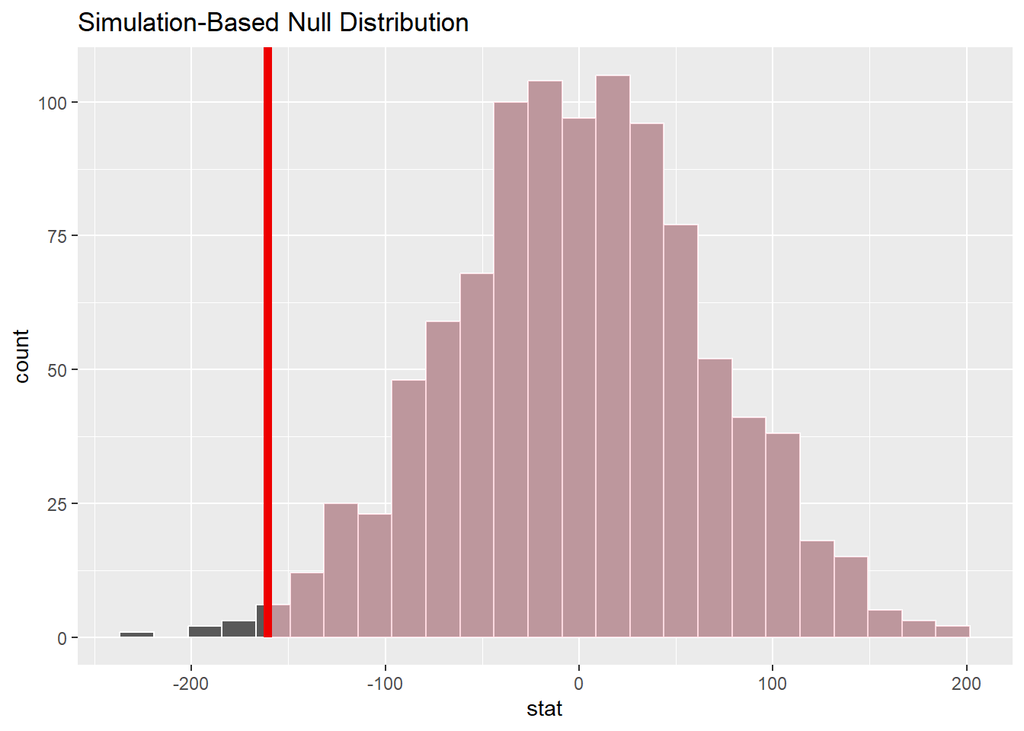

#### Step 4: Get p-value and interpret

```
## # A tibble: 1 × 1
##   p_value
##     <dbl>
## 1   0.991
```

p-value is much higher than our significance level and therefore we fail to reject the H0 in favour of the Ha. ie the number of admissions in winter is equal or less than the mean number of admissions for the rest of the year.

## Test 2: Is the winter rate of admissions different pre-covid?

Are the number of admissions in winter higher than in the rest of the year before Covid?

#### Step 1: Generate hypothesis

H0: mean(winter admissions pre_covid) = mean(rest of year admissions pre covid)

$$H_0: \mu_{\textrm{winter admissions
pre-covid}} - \mu_{\textrm{rest of year admissions pre-covid}}
<=0$$
H1: mean(winter admissions pre-covid) > mean(summer admissions pre-covid)

$$H_1: \mu_{\textrm{winter admissions
pre-covid}} - \mu_{\textrm{rest of year admissions pre-covid}}\ >
0$$

significance level = 0.05

#### Step 2: Calculate observed stat

```
## Response: number_of_attendances_aggregate (numeric)
## Explanatory: season (factor)
## # A tibble: 1 × 1
##    stat
##   <dbl>
## 1 -126.
```

#### Step 3: Generate null distribution and visualise

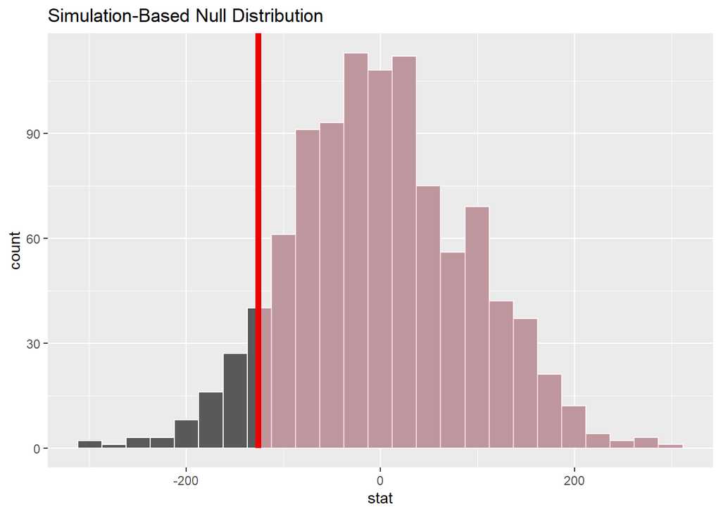

#### Step 4: Get p-value and interpret

```
## # A tibble: 1 × 1
##   p_value
##     <dbl>
## 1   0.924
```

Fail to reject the null hypothesis, ie the number of admissions to A&E in winter is the same as, or less than, admissions in the rest of the year.

## Test 3: Is the winter rate of admissions different post-covid

Are the number of admissions in winter higher than in the rest of the year after Covid?

#### Step 1: Generate hypothesis

H0: mean(winter admissions post_covid) = mean(rest of year admissions post covid)

$$H_0: \mu_{\textrm{winter admissions
post-covid}} - \mu_{\textrm{rest of year admissions post-covid}}
<=0$$
H1: mean(winter admissions post-covid) > mean(summer admissions post-covid)

$$H_1: \mu_{\textrm{winter admissions
post-covid}} - \mu_{\textrm{rest of year admissions post-covid}}\ >
0$$

significance level = 0.05

#### Step 2: Calculate observed stat

```
## Response: number_of_attendances_aggregate (numeric)
## Explanatory: season (factor)
## # A tibble: 1 × 1
##    stat
##   <dbl>
## 1 -234.
```

#### Step 3: Generate null distribution and visualise

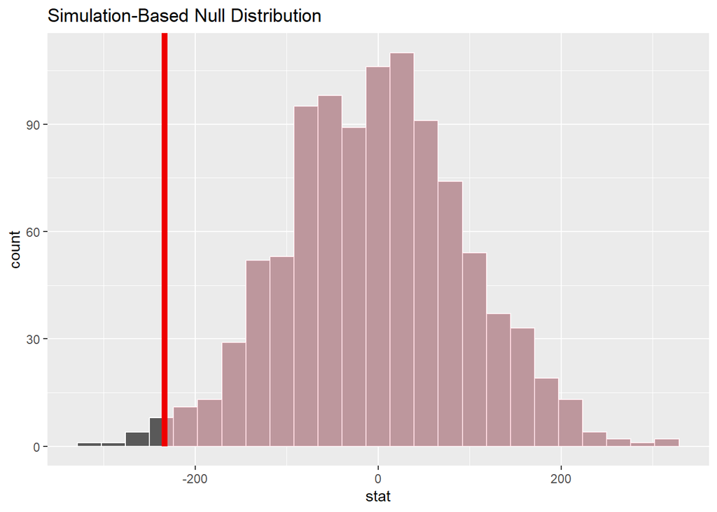

#### Step 4: Get p-value and interpret

```
## # A tibble: 1 × 1
##   p_value
##     <dbl>
## 1   0.989
```

Fail to reject the null hypothesis, ie the number of admissions to A&E in winter is the same as, or less than, admissions in the rest of the year.

## Test 4A: Are the number of people discharged home in winter higher than in the rest of the year?

Is there a higher discharge home rate in the summer compared to winter?

#### Step 1: Generate hypothesis

H0: mean(winter discharge home) = mean(rest of year discharge home)

$$H_0: \mu_{\textrm{rest of year
discharge home}} - \mu_{\textrm{winter discharge home}} <=0$$
H1: higher mean discharge home in rest of year compared to winter )

$$H_1: \mu_{\textrm{rest of year
discharged home}} - \mu_{\textrm{winter discharged
home}}>0$$

significance level = 0.05

#### Step 2: Calculate observed stat

```
## Response: discharge_destination_residence (numeric)
## Explanatory: season (factor)
## # A tibble: 1 × 1
##    stat
##   <dbl>
## 1  221.
```

#### Step 3: Generate null distribution and visualise

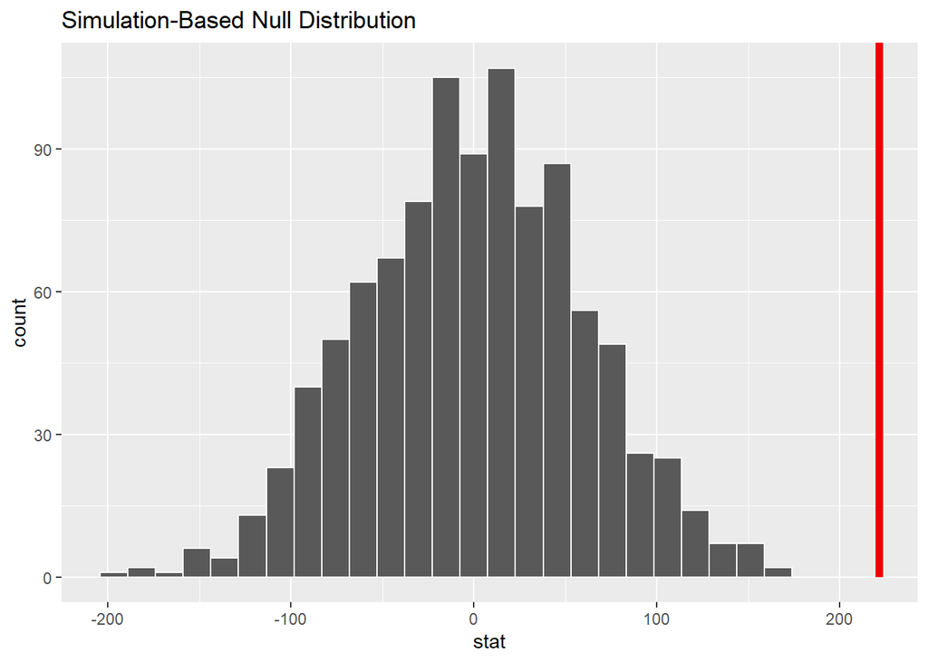

#### Step 4: Get p value and interpret

```
## # A tibble: 1 × 1
##   p_value
##     <dbl>
## 1       0
```

p-value is less than our significance level and therefore we reject the H0 in favour of the Ha: ie there is higher discharge to home rate in the summer compared to winter.

## Test 4B: Are the proportion of people discharged home in winter higher different from the rest of the year?

Are the proportions of patients to A&E discharged to home different in winter and the rest of the year. (Two means - independent)

#### Step 1: Generate hypothesis

H0: mean(proportion home discharged rest of year) - mean(proportion home discharge winter) <= 0

$$H_0: \mu_{\textrm{prop discharged rest
of year}} - \mu_{\textrm{prop discharge home winter }}
<=0$$

H1: mean(proportion home discharge rest of year) - mean(proportion home discharge winter) > 0

$$H_1: \mu_{\textrm{prop discharged rest
of year}} - \mu_{\textrm{prop discharge home winter}}>0$$

significance level = 0.05

#### Step 2: Calculate observed stat

```
## Response: prop_discharged_home (numeric)
## Explanatory: season (factor)
## # A tibble: 1 × 1
##     stat
##    <dbl>
## 1 0.0178
```

#### Step 3: Generate null distribution and visualise

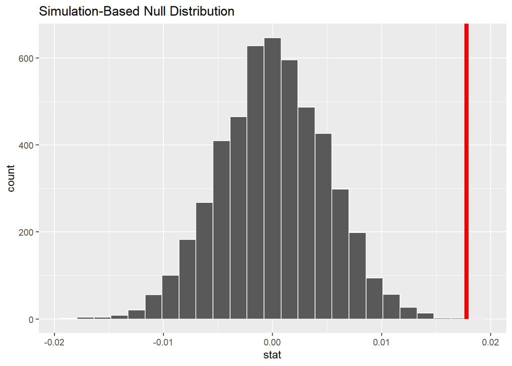

#### Step 4: Get p-value and interpret

```
## # A tibble: 1 × 1
##   p_value
##     <dbl>
## 1  0.0002
```

The p-value is less than our 0.05 significance level, and therefore we can reject the H0 in facour of the Ha. This means that we the proportion of patients that are discharged home is higher in the rest of the year, compared to in winter time.